# Exploratory Analysis

**Some exploratory data analysis of the Freddie Mac dataset**

```python
from IPython.display import HTML

HTML('''<script>
  function code_toggle() {
    if (code_shown){
      $('div.input').hide('500');
      $('#toggleButton').val('Show Code')
    } else {
      $('div.input').show('500');
      $('#toggleButton').val('Hide Code')
    }
    code_shown = !code_shown
  }

  $( document ).ready(function(){
    code_shown=false;
    $('div.input').hide()
  });
</script>
<form action="javascript:code_toggle()"><input type="submit" id="toggleButton" value="Show Code"></form>''')
```

```python
import pandas as pd
import numpy as np
import matplotlib.pyplot as plt
import matplotlib.dates as mdates
import datetime
%matplotlib inline
pd.options.display.max_columns = None
pd.options.display.max_rows = 10
```

```python
origination_columns = ['credit_score','first_payment_date','first_time_homebuyer','maturity_date',
                      'metropolitan_statistical_area','mortgage_insurance_pct','number_units',
                      'occupancy_status','original_cltv','original_dti','original_upb',
                      'original_ltv','original_interest_rate','channel','prepayment_penalty',
                      'product_type','state','property_type','postal_code','loan_sequence_number',
                      'loan_purpose','original_loan_term','number_of_borrowers','seller_name',
                      'servicer_name','super_conforming_flag']

monthly_performance_columns = ['loan_sequence_number','monthly_reporting_period','current_actual_upb',
                              'current_delinquency_status','loan_age','months_to_legal_maturity',
                              'repurchase_flag','modification_flag','zero_balance_code',
                              'zero_balance_effective_date','current_interest_rate','current_deferred_upb',
                              'due_date_last_paid_installment','mi_recoveries','net_sales_proceeds',
                              'non_mi_recoveries','expenses','legal_costs','maintenance_preservation_costs',
                              'taxes_and_insurance','misc_expenses','actual_loss','modification_cost',
                              'step_modification_flag','deferred_payment_modification','estimated_ltv']
```

```python
# import origination file and rename columns
data_sample = pd.read_csv('sample_orig_2001.txt', sep="|", header=None)
data_sample.columns = origination_columns

# import monthly performance file and rename columns
data_sample_time = pd.read_csv('sample_svcg_2001.txt', sep="|", header=None)
data_sample_time.columns = monthly_performance_columns
```

Here we pull out one loan (sequence number F101Q1030957) that defaults to see what a default looks like.

```python
data_sample[data_sample['loan_sequence_number']=='F101Q1030957']
```

|  | credit_score | first_payment_date | first_time_homebuyer | maturity_date | metropolitan_statistical_area | mortgage_insurance_pct | number_units | occupancy_status | original_cltv | original_dti | original_upb | original_ltv | original_interest_rate | channel | prepayment_penalty | product_type | state | property_type | postal_code | loan_sequence_number | loan_purpose | original_loan_term | number_of_borrowers | seller_name | servicer_name | super_conforming_flag |
| --- | --- | --- | --- | --- | --- | --- | --- | --- | --- | --- | --- | --- | --- | --- | --- | --- | --- | --- | --- | --- | --- | --- | --- | --- | --- | --- |
| 1080 | 653 | 200105 | Y | 203104 | 16974.0 | 27 | 1 | P | 95 | 31 | 127000 | 95 | 7.75 | T | N | FRM | IL | SF | 60400.0 | F101Q1030957 | P | 360 | 1 | Other sellers | Other servicers | NaN |

```python
data_sample_time[data_sample_time['loan_sequence_number']=='F101Q1030957']
```

|  | loan_sequence_number | monthly_reporting_period | current_actual_upb | current_delinquency_status | loan_age | months_to_legal_maturity | repurchase_flag | modification_flag | zero_balance_code | zero_balance_effective_date | current_interest_rate | current_deferred_upb | due_date_last_paid_installment | mi_recoveries | net_sales_proceeds | non_mi_recoveries | expenses | legal_costs | maintenance_preservation_costs | taxes_and_insurance | misc_expenses | actual_loss | modification_cost | step_modification_flag | deferred_payment_modification | estimated_ltv |
| --- | --- | --- | --- | --- | --- | --- | --- | --- | --- | --- | --- | --- | --- | --- | --- | --- | --- | --- | --- | --- | --- | --- | --- | --- | --- | --- |
| 35459 | F101Q1030957 | 200104 | 127000.00 | 0 | 0 | 360 | NaN | NaN | NaN | NaN | 7.75 | 0.0 | NaN | NaN | NaN | NaN | NaN | NaN | NaN | NaN | NaN | NaN | NaN | NaN |  | NaN |
| 35460 | F101Q1030957 | 200105 | 127000.00 | 0 | 1 | 359 | NaN | NaN | NaN | NaN | 7.75 | 0.0 | NaN | NaN | NaN | NaN | NaN | NaN | NaN | NaN | NaN | NaN | NaN | NaN |  | NaN |
| 35461 | F101Q1030957 | 200106 | 127000.00 | 0 | 2 | 358 | NaN | NaN | NaN | NaN | 7.75 | 0.0 | NaN | NaN | NaN | NaN | NaN | NaN | NaN | NaN | NaN | NaN | NaN | NaN |  | NaN |
| 35462 | F101Q1030957 | 200107 | 127000.00 | 0 | 3 | 357 | NaN | NaN | NaN | NaN | 7.75 | 0.0 | NaN | NaN | NaN | NaN | NaN | NaN | NaN | NaN | NaN | NaN | NaN | NaN |  | NaN |
| 35463 | F101Q1030957 | 200108 | 127000.00 | 0 | 4 | 356 | NaN | NaN | NaN | NaN | 7.75 | 0.0 | NaN | NaN | NaN | NaN | NaN | NaN | NaN | NaN | NaN | NaN | NaN | NaN |  | NaN |
| ... | ... | ... | ... | ... | ... | ... | ... | ... | ... | ... | ... | ... | ... | ... | ... | ... | ... | ... | ... | ... | ... | ... | ... | ... | ... | ... |
| 35495 | F101Q1030957 | 200404 | 134784.85 | 11 | 36 | 342 | NaN | NaN | NaN | NaN | 7.75 | 0.0 | NaN | NaN | NaN | NaN | NaN | NaN | NaN | NaN | NaN | NaN | NaN | NaN |  | NaN |
| 35496 | F101Q1030957 | 200405 | 134784.85 | 12 | 37 | 341 | NaN | NaN | NaN | NaN | 7.75 | 0.0 | NaN | NaN | NaN | NaN | NaN | NaN | NaN | NaN | NaN | NaN | NaN | NaN |  | NaN |
| 35497 | F101Q1030957 | 200406 | 134784.85 | 13 | 38 | 340 | NaN | NaN | NaN | NaN | 7.75 | 0.0 | NaN | NaN | NaN | NaN | NaN | NaN | NaN | NaN | NaN | NaN | NaN | NaN |  | NaN |
| 35498 | F101Q1030957 | 200407 | 134784.85 | R | 39 | 339 | NaN | NaN | NaN | NaN | 7.75 | 0.0 | NaN | NaN | NaN | NaN | NaN | NaN | NaN | NaN | NaN | NaN | NaN | NaN |  | NaN |
| 35499 | F101Q1030957 | 200411 | 0.00 | R | 0 | 0 | N | NaN | 9.0 | 200411.0 | 0.00 | 0.0 | 200304.0 | 37630.0 | 152100 | 46.0 | -17640.0 | 0.0 | 0.0 | 0.0 | 0.0 | 21559.0 | 0.0 | NaN |  | NaN |

41 rows × 26 columns

Note that the default does not happen immediately, but there is a pattern where someone is delinquent for awhile, and then it is sold which is represented by 'R'. Also note that once something defaults it is not until a few months later that the actual loss shows up.

Also it is worth noting the calculation of Actual Loss:

**Actual Loss** = (Default UPB – Net Sale_Proceeds) + Delinquent Accrued Interest - Expenses – MI Recoveries – Non MI Recoveries

**Delinquent Accrued Interest** = (Default_UPB – Non Interest bearing UPB) *(Current Interest rate – 0.35)* ( Months between Last Principal & Interest paid to date and zero balance date ) * 30/360/100

*0.35 is the assumed servicing fee*

So even though the sale price will be higher than the default UPB you can still have positive actual losses.

**Delinquency Evolution of One Loan**

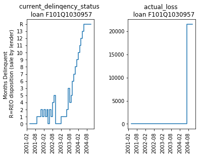

```python
months =  pd.to_datetime(data_sample_time[data_sample_time['loan_sequence_number']=='F101Q1030957']['monthly_reporting_period'], format='%Y%m')
myFmt = mdates.DateFormatter('%Y-%m')

f, (ax1, ax2) = plt.subplots(1, 2)

ax1.step(months,data_sample_time[data_sample_time['loan_sequence_number']=='F101Q1030957']['current_delinquency_status'])
ax1.set_title('current_delinqency_status \n loan F101Q1030957')
ax1.set_ylabel('Months Delinquent \n R=REO disposition (sale by lender)')
ax1.set_xticklabels(months,rotation=90)
ax1.xaxis.set_major_formatter(myFmt)

ax2.step(months,data_sample_time[data_sample_time['loan_sequence_number']=='F101Q1030957']['actual_loss'].fillna(0))
ax2.set_title('actual_loss \n  loan F101Q1030957')
ax2.set_xticklabels(months,rotation=90)
ax2.xaxis.set_major_formatter(myFmt)

plt.subplots_adjust(left=None, bottom=None, right=None, top=None, wspace=0.5, hspace=None)
plt.show()
```

**Delinquency Evolution of Defaulting and Non-Defaulting Loans**

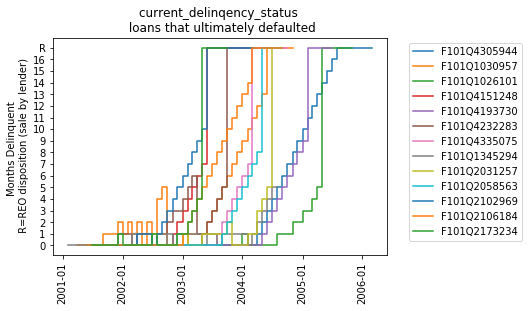

```python
f, (ax1) = plt.subplots(1, 1)

delinquent_loan_ids = ['F101Q4305944','F101Q1030957','F101Q1026101','F101Q4151248','F101Q4193730',
                      'F101Q4232283','F101Q4335075','F101Q1345294',
                      'F101Q2031257','F101Q2058563','F101Q2102969','F101Q2106184',
                      'F101Q2173234']


for loan_id in delinquent_loan_ids:
    months =  pd.to_datetime(data_sample_time[data_sample_time['loan_sequence_number']==loan_id]['monthly_reporting_period'], format='%Y%m')
    ax1.step(months,data_sample_time[data_sample_time['loan_sequence_number']==loan_id]['current_delinquency_status'])

ax1.set_title('current_delinqency_status \n loans that ultimately defaulted')
ax1.set_ylabel('Months Delinquent \n R=REO disposition (sale by lender)')
ax1.xaxis.set_major_formatter(myFmt)
plt.xticks(rotation=90)
plt.gca().legend(delinquent_loan_ids,bbox_to_anchor=(1.05, 1),loc=2)
plt.show()
```

Delinquency of some loans that never actually defaulted

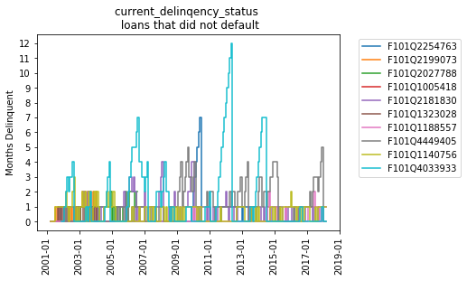

```python
q = data_sample_time[['loan_sequence_number','current_delinquency_status','actual_loss']].fillna(0)
q = pd.DataFrame(q.groupby(by=['loan_sequence_number'])[['actual_loss','current_delinquency_status']].sum())
q = q[q['actual_loss']==0]
q.reset_index(level=0,inplace=True)
q = data_sample_time[data_sample_time['loan_sequence_number'].isin(q['loan_sequence_number'])]
q = q[q['current_delinquency_status']=='1']
q = q.sample(n=10,random_state=1)['loan_sequence_number']

f, (ax1) = plt.subplots(1, 1)

delinquent_loan_ids = q.values


for loan_id in delinquent_loan_ids:
    months =  pd.to_datetime(data_sample_time[data_sample_time['loan_sequence_number']==loan_id]['monthly_reporting_period'], format='%Y%m')
    ax1.step(months,data_sample_time[data_sample_time['loan_sequence_number']==loan_id]['current_delinquency_status'])

ax1.set_title('current_delinqency_status \n loans that did not default')
ax1.set_ylabel('Months Delinquent')
ax1.xaxis.set_major_formatter(myFmt)
plt.xticks(rotation=90)
plt.gca().legend(delinquent_loan_ids,bbox_to_anchor=(1.05, 1),loc=2)
plt.show()
```

Let's take a look at the distribution of some loans (default vs. no default) across some metrics

```python
list_defaulted_loans = data_sample_time[data_sample_time['actual_loss']>0]['loan_sequence_number']
```

```python
defaulted_details = data_sample[data_sample['loan_sequence_number'].isin(list_defaulted_loans)]
non_defaulted_details = data_sample[~data_sample['loan_sequence_number'].isin(list_defaulted_loans)]
```

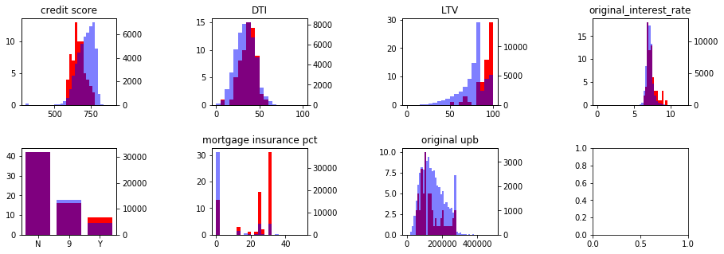

```python
plt.figure(1,figsize=(5,5))

f, ((ax1, ax2,ax3,ax4), (ax5, ax6,ax7,ax8)) = plt.subplots(2, 4,figsize=(15,5))



# by credit score
credit_bin_edges = np.arange(300, 920, 20)
ax1.hist(defaulted_details[defaulted_details['credit_score']<9999]['credit_score'],
         bins=credit_bin_edges,color='red')
ax1b = ax1.twinx()
ax1b.hist(non_defaulted_details[non_defaulted_details['credit_score']<9999]['credit_score'],
        bins=credit_bin_edges,color='blue',alpha=0.5)
ax1.set_title('credit score')

# by DTI
dti_bin_edges = np.arange(0, 105, 5)
ax2.hist(defaulted_details[defaulted_details['original_dti']<500]['original_dti'],
         bins=dti_bin_edges,color='red')
ax2b = ax2.twinx()
ax2b.hist(non_defaulted_details[non_defaulted_details['original_dti']<500]['original_dti'],
        bins=dti_bin_edges,color='blue',alpha=0.5)
ax2.set_title('DTI')

# by LTV
ltv_bin_edges = np.arange(0, 105, 5)
ax3.hist(defaulted_details[defaulted_details['original_ltv']<500]['original_ltv'],
         bins=ltv_bin_edges,color='red')
ax3b = ax3.twinx()
ax3b.hist(non_defaulted_details[non_defaulted_details['original_ltv']<500]['original_ltv'],
        bins=ltv_bin_edges,color='blue',alpha=0.5)
ax3.set_title('LTV')

# by rate
rate_bin_edges = np.arange(0, 12, .25)
ax4.hist(defaulted_details[defaulted_details['original_interest_rate']<50]['original_interest_rate'],
         bins=rate_bin_edges,color='red')
ax4b = ax4.twinx()
ax4b.hist(non_defaulted_details[non_defaulted_details['original_interest_rate']<50]['original_interest_rate'],
        bins=rate_bin_edges,color='blue',alpha=0.5)
ax4.set_title('original_interest_rate')

# by first_time_homebuyer
ax5.bar(list(defaulted_details['first_time_homebuyer'].value_counts().index),
        list(defaulted_details['first_time_homebuyer'].value_counts().values),color='red')
ax5b = ax5.twinx()
ax5b.bar(list(non_defaulted_details['first_time_homebuyer'].value_counts().index),
        list(non_defaulted_details['first_time_homebuyer'].value_counts().values),color='blue',alpha=.5)

# by mortgage insurance pct
mtg_insur_bin_edges = np.arange(0, 52, 2)
ax6.hist(defaulted_details[defaulted_details['mortgage_insurance_pct']<500]['mortgage_insurance_pct'],
         bins=mtg_insur_bin_edges,color='red')
ax6b = ax6.twinx()
ax6b.hist(non_defaulted_details[non_defaulted_details['mortgage_insurance_pct']<500]['mortgage_insurance_pct'],
        bins=mtg_insur_bin_edges,color='blue',alpha=0.5)
ax6.set_title('mortgage insurance pct')

# original unpaid balance
orig_upb_bin_edges = np.arange(0, 500000, 10000)
ax7.hist(defaulted_details[defaulted_details['original_upb']<99999999]['original_upb'],
         bins=orig_upb_bin_edges,color='red')
ax7b = ax7.twinx()
ax7b.hist(non_defaulted_details[non_defaulted_details['original_upb']<999999999]['original_upb'],
        bins=orig_upb_bin_edges,color='blue',alpha=0.5)
ax7.set_title('original upb')

plt.subplots_adjust(left=None, bottom=None, right=None, top=None, wspace=1, hspace=0.5)
plt.show()
```